# HW1 - SDS

## 1.3

We have not achieved our goal. The algorithm does not satisfy the fourth requirement since it uses the required words of space in its entirety (i.e., $O(log(n)$) just for storing the vector $y$. Hence the projection matrix $L$, using $O(p*d)$ words of space where $p∼log(n)/eps^2$, would by no means fit in the memory requirement, in fact $O(log(n) + d*log(n)/eps^2)>O(log(n))$ with $d$≠0.

We propose the following workaround: Since $L$ remains constant during all the iterations, and given that it is the result of sampling from a normal distribution with known parameters, we could just resample at each iteration the “needed quantities” exploiting the functionality of the seed. The seed has a maximum value it can take, namely:

```r
.Machine$integer.max
```

```
## [1] 2147483647
```

Thus, we cannot use a different seed value to generate the each and every column of the matrix (specifically the j-th column to add to $y$), given that there are $d$ columns and $d$ is a really large number (additionally, in order to have different $L$ matrices for every simulation, we would have to multiply it by the simulation number, ending up with a seed value that would even exeed the value of $d$). Hence, we could instead use the seed to generate the matrix itself, at each iteration of the stream, iteratively by keeping in memory just one column at a time. In this way the words of space used would be $O(p)$ for the i-th column of L (until we get to i=j), and $O(p)$ for vector $y$, thus $O(p+p)=O(p)=O(log(n)/eps^2)$.

```r
# 1.3 - Simulation --------------------------------------------------------
epsilon <- 0.9
p <- 16/epsilon**2 # 100
n <- 300
d <- 1000
M<-1000
v <- NULL
bound <- 1 - exp(-epsilon**(2)*p)

for(s in 1:M){
  x<-rep(0,d)
  y<-rep(0,p)
  y_old<-y
  for(i in 1:n){
    set.seed(s) #to avoid having the same L matrix at each simulation
    j <- sample(1:d,1)
    x[j]=x[j]+1

    k<-0
    while (k!=j){
      tempCol <- rnorm(p,mean=0,sd=sqrt(1/p))
      k=k+1
    }
    jCol <-tempCol
    y = y+jCol
  }

  norm_x = sqrt(sum(x**2))
  norm_y = sqrt(sum(y**2))
  right_hs <- norm_x*(1+epsilon) # right hand-side
  left_hs <- norm_x*(1-epsilon) # left hand-side
  # check if the inequalities are both verified
  jl <- norm_y >= left_hs && norm_y <= right_hs
  # for each simulation, store if the inequalities are both verified or not
  v[s] <- jl
}

percentage_true <- sum(v)/M
print(percentage_true)
bound
```

[output not shown]

Here, since the probability is 1 and bound=0.9999999, the JL lemma is verified once again.

Just for reference, we include also the code using different seeds to create the columns of L (note that this does not always work)

```r
jth_vector = function(seed, L, p){
  # the seed is the index (i.e., j), such that if the same index is passed,
  #we recreate the same vector (i.e., the same j-th column of L)
  set.seed(seed)

  # sample p indexes, which will refer to values of the L vector
  vector = sample(1:length(L), p)
  # return the j-th column of L
  return(L[vector])
}

set.seed(42) # to replicate results

M <- 1000 # simulation size

# Define necessary parameters
epsilon <- 2
p <- 16/epsilon**2 # 100
n <- 30
d <- 1000


bound <- 1 - exp(-epsilon**(2)*p) # bound respected with the JL
v <- NULL # initialize vector that will contain

# generate L
# it will not be a p by d matrix, but a vector
L = rnorm(p * 2, mean = 0, sd = 1/sqrt(p))

# Start simulation
# Repeat M times
for (simulation in 1:M) {
  y = rep(0,p) # initialize y vector
  x = rep(0,d) # initialize x vector

  # at each simulation, change the seed (otherwise, we always get the same indexes)
  set.seed(42 * simulation)

  # Algorithm
  for(j in 1:n){

    set.seed(42 * simulation * j)

    # access value of j-th element in the stream (without generating the stream)
    stream_value  = sample(1:d, 1)

    # add one to j-th element of x (here, j = stream_value)
    x[stream_value] = x[stream_value] + 1
    # update y after having generated a specific j-th vector
    # (a combination of p values of L, specific for j)
    y = y + jth_vector(stream_value, L, p)
  }

  # as in point 2
  norm_x = sqrt(sum(x**2))
  norm_y = sqrt(sum(y**2))

  right_hs <- norm_x*(1+epsilon) # right hand-side
  left_hs <- norm_x*(1-epsilon) # left hand-side

  # check if the inequalities are both verified
  jl <- norm_y >= left_hs && norm_y <= right_hs
  # for each simulation, store if the inequalities are both verified or not
  v[simulation] <- jl
}

# count how many times the inequalities are both verified out of M simulations
percentage_true <- sum(v)/M
print(percentage_true)
bound
```

# EXERCISE 2

## 2.1

For a probability density function to be legit, we must impose two conditions:

1. It is non-negative everywhere:
   $$\hat{f}(x) = \sum_{j=1}^{N}\frac{\pi_j}{h} \mathbb{1}(x \epsilon B_j) \ge 0$$
   which implies that $\pi_j \ge 0$
2. It integrates to 1 over its support:

$$\begin{equation}
\int_0^1 \hat{f}(x) \, dx = \int_0^1 \sum_{j=1}^{N}\frac{\pi_j}{h} \mathbb{1}(x \epsilon B_j) \, dx = 1
\end{equation}$$

$$\begin{equation}
\int_0^1 \sum_{j=1}^{N}\frac{\pi_j}{h} \mathbb{1}(x \epsilon B_j) \, dx =
\sum_{j=1}^{N}\frac{\pi_j}{h} \int_0^1 \mathbb{1}(x \epsilon B_j) \, dx = \\
= \sum_{j=1}^{N}\frac{\pi_j}{h} \int_{B_{j - 1}}^{B_j} \, dx = \\
\sum_{j=1}^{N}\frac{\pi_j}{h} * h = 1
\\
\sum_{j=1}^{N} \pi_j = 1
\end{equation}$$

## 2.2

To implement the density function f_hat and its quantile, we first generate the $\pi$’s using the function GeneratorPi, which provides us with N positive $\pi$’s that sum up to 1. That is, we create N $\pi$’s such that the above conditions are respected.

```r
# generate N pi's that sum up to 1 (where N = ceiling(1/h))
GeneratorPi <- function(h){pi <- runif(ceiling(1/h),0,1); pi <- pi/sum(pi); return(pi)}
```

We implement the approximating density f_hat giving it as parameters x, h, $\pi$ and the possibility to create a graph. For each x, it will return the corresponding $\pi$/h, which will be needed further on.

```r
library(data.table)

f_hat <- function(x, h, pi, graph =FALSE){
  N <- ceiling(1/h)

  # generate intervals of length h between 0 and 1
  B_j <- seq(0, 1, h)

  # initialize vector of y's. To each x we will have an associated y
  y <- c()
  if(sum(pi)!=1){stop(cat("The condition on pi's is not respected as the sum is ", sum(pi),".
                          It should be = 1"))}

  # loop on the bins
  for(i in 1:N){

    # loop on the elements of x
    for(j in 1:length(x)){
      if(pi[i]<0){errorCondition("The pi's are not all positive")}

      # For each x, find the bin to which it belongs to and associate to it the pi of that bin (y)
      if( between(x[j],B_j[i],B_j[i+1])){y[j] <- pi[i]/h}
    }}

  # generate graph
  if(graph == TRUE){plot(x,y,ylim = c(0,max(y)+1)); lines(x,y,type = "s")}
  return(y)
}
```

```r
# example
x <- seq(0, 1, 0.01)
h <- 0.2
# generate pi's
pi <- GeneratorPi(h)

# verify that they sum up to 1
sum(pi)
```

```
## [1] 1
```

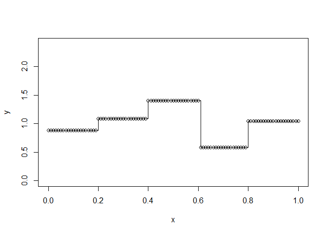

```
##   [1] 0.8876554 0.8876554 0.8876554 0.8876554 0.8876554 0.8876554 0.8876554
##   [8] 0.8876554 0.8876554 0.8876554 0.8876554 0.8876554 0.8876554 0.8876554
##  [15] 0.8876554 0.8876554 0.8876554 0.8876554 0.8876554 0.8876554 1.0858836
##  [22] 1.0858836 1.0858836 1.0858836 1.0858836 1.0858836 1.0858836 1.0858836
##  [29] 1.0858836 1.0858836 1.0858836 1.0858836 1.0858836 1.0858836 1.0858836
##  [36] 1.0858836 1.0858836 1.0858836 1.0858836 1.0858836 1.4011404 1.4011404
##  [43] 1.4011404 1.4011404 1.4011404 1.4011404 1.4011404 1.4011404 1.4011404
##  [50] 1.4011404 1.4011404 1.4011404 1.4011404 1.4011404 1.4011404 1.4011404
##  [57] 1.4011404 1.4011404 1.4011404 1.4011404 1.4011404 0.5808554 0.5808554
##  [64] 0.5808554 0.5808554 0.5808554 0.5808554 0.5808554 0.5808554 0.5808554
##  [71] 0.5808554 0.5808554 0.5808554 0.5808554 0.5808554 0.5808554 0.5808554
##  [78] 0.5808554 0.5808554 0.5808554 1.0444652 1.0444652 1.0444652 1.0444652
##  [85] 1.0444652 1.0444652 1.0444652 1.0444652 1.0444652 1.0444652 1.0444652
##  [92] 1.0444652 1.0444652 1.0444652 1.0444652 1.0444652 1.0444652 1.0444652
##  [99] 1.0444652 1.0444652 1.0444652
```

```r
# compute f_hat
f_hat(x, h, pi, graph = TRUE)
```

### QUANTILE FUNCTION

We carry on with the implementation of the quantile function, which - for each quantile level q we provide it with - will return us the smallest value of x such that the CDF is at least q.

```r
quant <- function(q, pi, h, graph=F){

  # build cdf
  cdf <- cumsum(pi)

  # bins
  B <- seq(0,1,h)
  N <- ceiling(1/h)

  # create plot
  if (graph == TRUE){
    plot(B, c(cdf, 1), type="s", main = "CDF and Quantiles",ylim = c(0,1),xlim = c(0,1), ylab = "q")
    abline(v = c(0,B), lty = 3,col ="WHITE")
    abline(h = q, lty = 2, col="red",lwd=2)}

  if(length(pi) != N){stop("Number of pi's differs from number of bins")}

  # return 0
  if(q < cdf[1]){return(0)}

  # if q is between two steps, return first value of larger step
  # (remember that each step starts where a new bin starts)
  for(i in 1:N){if(between(q,cdf[i],cdf[i+1])){return(B[i+1])}

    # if q is at the same height of a bin, return the starting value of that bin
    if(q==cdf[i]){return(B[i])}
  }
}
```

```r
# find a few quantiles and plot them together with the cdf
h <- 0.2
pi <- GeneratorPi(h)
sum(pi)
```

```
## [1] 1
```

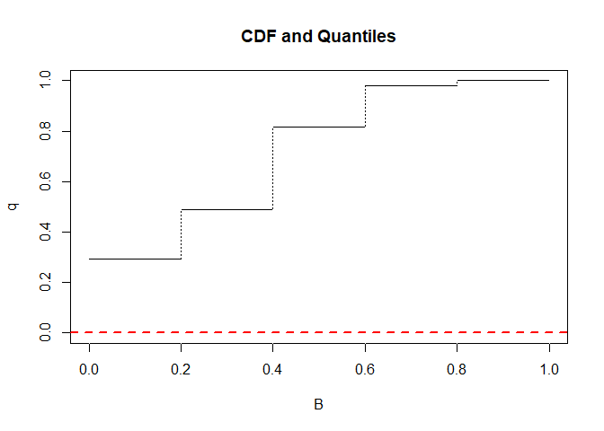

```
## At the level 0 , the quantile is:  0
```

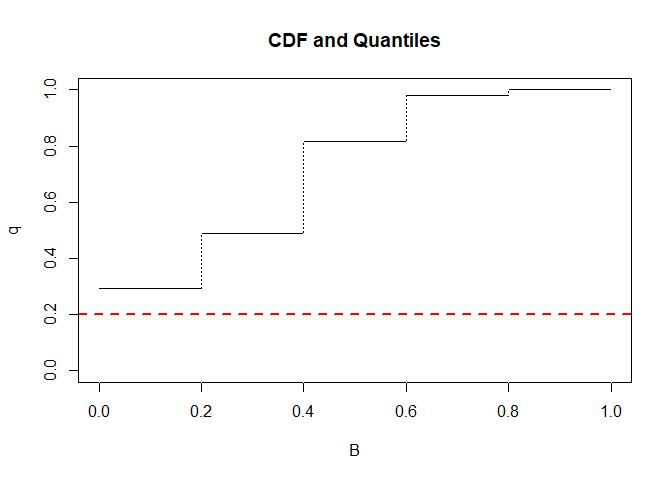

```
## At the level 0.2 , the quantile is:  0
```

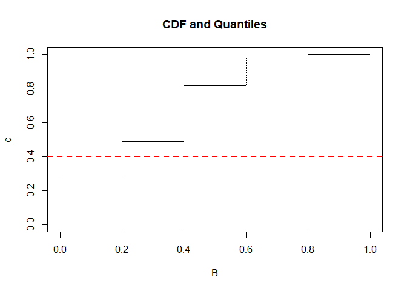

```
## At the level 0.4 , the quantile is:  0.2
```

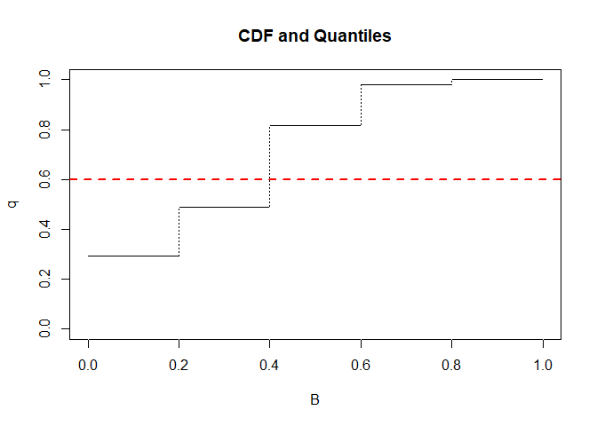

```
## At the level 0.6 , the quantile is:  0.4
```

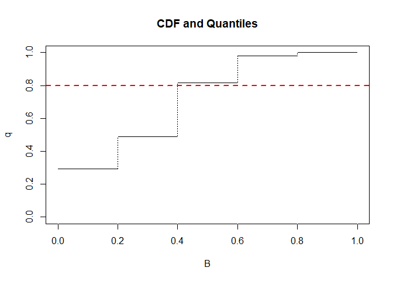

```
## At the level 0.8 , the quantile is:  0.4
```

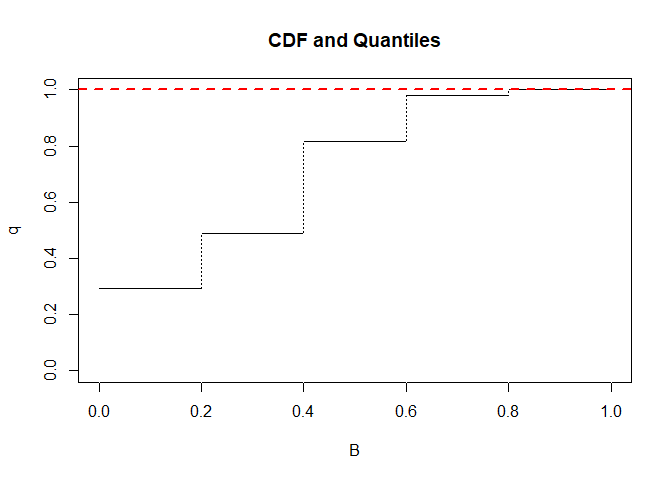

```
## At the level 1 , the quantile is:  0.8
```

```r
for(q in seq(0,1,0.2)){
  cat("At the level", q, ", the quantile is: ", quant(q,pi,h, graph = T),"\n")
}
```